# XML HW4 - Tomasz Cheda

## Intro

I trained a RandomForest Classifier with 100 estimators on the phoneme dataset.

I performed a random 80/20 train/test split to estimate model performance.

All shapley values are calculated on the training set. For all models, the data is passed through a StandardScaler.

The RandomForestClassifier exhibited some overfitting:

| Metric | TRAIN | TEST |
| --- | --- | --- |
| Accuracy Score | 0.999 | 0.911 |
| Precision Score | 1.000 | 0.841 |
| Recall Score | 0.999 | 0.857 |
| F1 Score | 0.999 | 0.849 |
| AUC-ROC Score | 1.000 | 0.962 |

I then selected two observations, one with each label. Both were correctly classified by the model.

## Dalex vs Shap

I then produced an explanation with dalex:

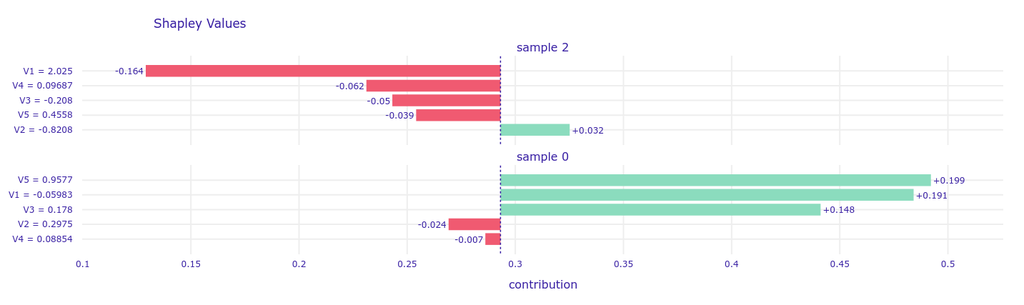

And with shap:

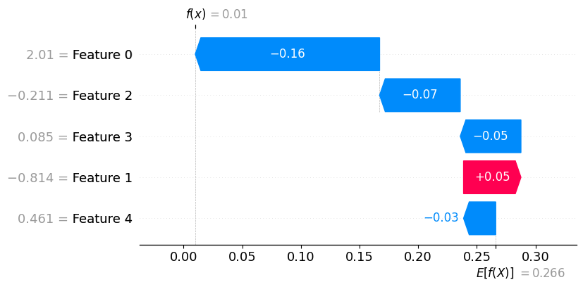

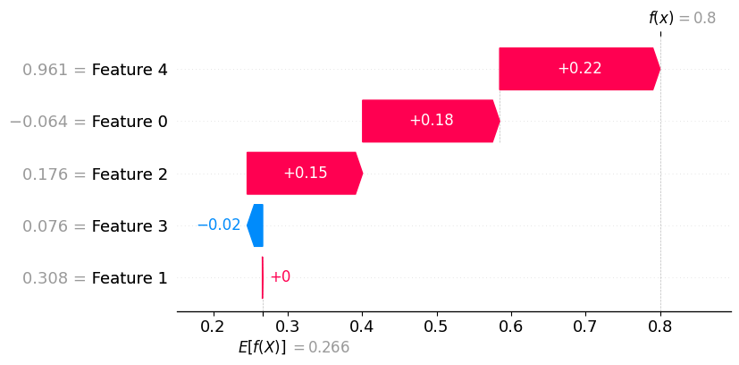

While there are small differences - shap uses zero-based indexing for features, and the feature values shown are after scaling - the two implementations mostly agree on the attributions.

In case of the second sample, they are nearly unanimous. In case of the first sample, they agree on the direction of the influence, but reorder the magnitutes of 2nd/3rd and 4th/5th strongest features - the changes aren't big.

## Different most important variables

In this section I used the explanations from shap

I found the two samples by finding one sample with the max sum of importances of features 0 and 1, and another with max sum of importances of features 3 and 4

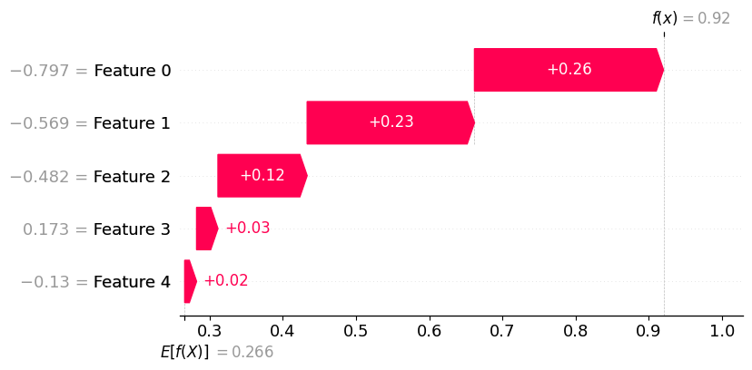

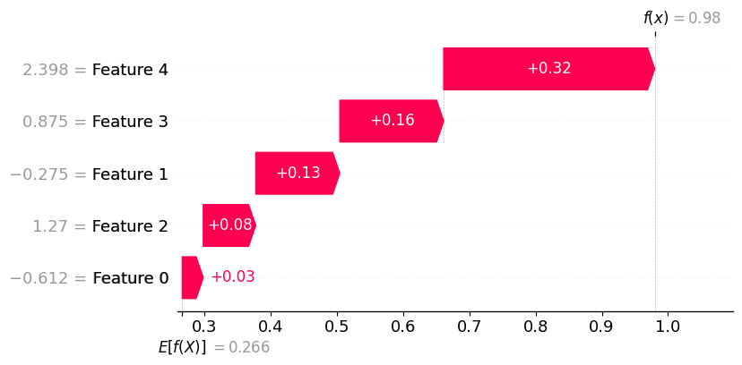

## Opposite attributions

In this section I also used shap output

In this case, I found the samples with highest and lowest shapley value of feature 0. Their existence suggests there are non-additive interactions (expected in a tree-based model)

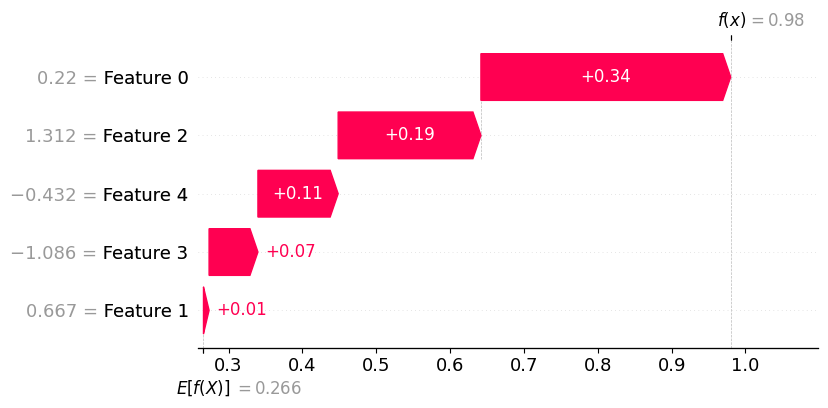

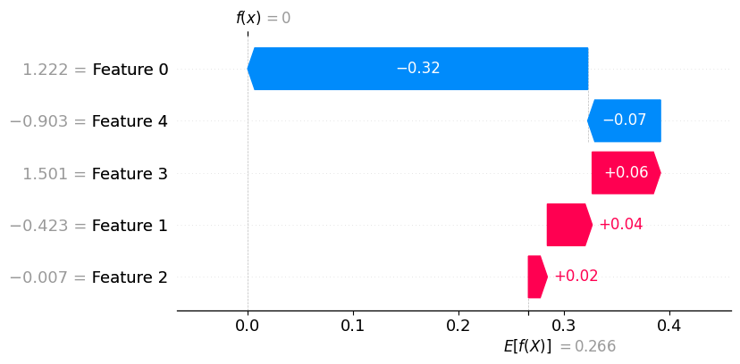

## Logistic regression and its attribution

I trained a logistic regression model with the default settings.

The model wasn't quite expressive enough and underfit.

| Metric | TRAIN | TEST |
| --- | --- | --- |
| Accuracy Score | 0.749 | 0.756 |
| Precision Score | 0.593 | 0.605 |
| Recall Score | 0.465 | 0.459 |
| F1 Score | 0.521 | 0.522 |
| AUC-ROC Score | 0.812 | 0.819 |

I used shap to produce explanations for the whole training set, and found the sample with the maximum magnitude of mismatch between LR and RFC, summed across features.

RFC:

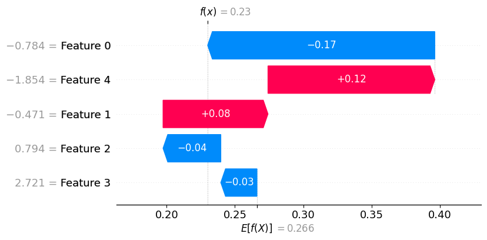

LR

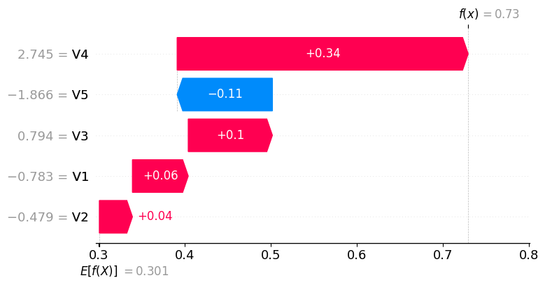

The small differences between feature values correspond to the fact that for LR the values are shown entering the pipeline with the scaler, and for RFC just the model.

## Summary

The experiments show that local additive explanations may yield somewhat unintuitive results, especially when evaluated on models which explicitly encourage non-additive interactions.

## Task B

Joining empty set: 20, 2 permutations

Joining set B: 60-20=40, 1 permutations

Joining set C: 70-60=10, 1 permutations

Joining set BC: 100-70=30, 2 permutations

Total 6 permutations

Shapley value for player A:

(2*20 + 40 + 10 + 2*30)/6 = (40+40+10+60)/6=150/6=25

# Appendix

## Setup

```python
!pip install openml
!pip install dalex
!pip install shap
```

```python
from sklearn.model_selection import train_test_split
from sklearn.ensemble import RandomForestClassifier
from sklearn.metrics import accuracy_score
from sklearn.pipeline import Pipeline
from sklearn.linear_model import LogisticRegression
from sklearn.preprocessing import StandardScaler, LabelEncoder
from sklearn.datasets import fetch_openml
import dalex as dx
import shap
import pandas as pd
import numpy as np
np.random.seed(42)

X, y = fetch_openml('phoneme', return_X_y=True) #Turns out there's a simpler way than the one I used in earlier labs. I checked the data seems to be the same.
#Avoid issues with categorical adnn 1/2 istead of 0/1
le = LabelEncoder()
y = le.fit_transform(y)

X_train, X_test, y_train, y_test = train_test_split(X, y, test_size=0.2, random_state=42)
```

[output not shown]

```python
#Lifted straight from HW2
from sklearn.metrics import make_scorer, accuracy_score, precision_score, recall_score, f1_score, roc_auc_score

def score_set(true, pred, prob):
  accuracy = accuracy_score(true, pred)
  precision = precision_score(true, pred)
  recall = recall_score(true, pred)
  f1 = f1_score(true, pred)
  rocauc = roc_auc_score(true, prob)

  print("Accuracy Score:", accuracy)
  print("Precision Score:", precision)
  print("Recall Score:", recall)
  print("F1 Score:", f1)
  print("AUC-ROC Score:", rocauc)


def score_single(model, xtrain, ytrain, xtest, ytest):
  model.fit(xtrain, ytrain)

  train_pred = model.predict(xtrain)
  train_prob = model.predict_proba(xtrain)[:, 1]

  test_pred = model.predict(xtest)
  test_prob = model.predict_proba(xtest)[:, 1]

  print("TRAIN:")
  score_set(ytrain, train_pred, train_prob)

  print("TEST:")
  score_set(ytest, test_pred, test_prob)
```

## Training RFC

```python
pipeline = Pipeline([
    ('scaler', StandardScaler()),
    ('rf_classifier', RandomForestClassifier(n_estimators=100, random_state=42))
])

pipeline.fit(X_train, y_train)
y_pred = pipeline.predict(X_test)
accuracy = accuracy_score(y_test, y_pred)
print("Accuracy:", accuracy)
```

```
Accuracy: 0.9111933395004626
```

```python
score_single(pipeline, X_train, y_train, X_test, y_test)
```

```
TRAIN:
Accuracy Score: 0.9997686791579922
Precision Score: 1.0
Recall Score: 0.9992138364779874
F1 Score: 0.9996067636649627
AUC-ROC Score: 1.0
TEST:
Accuracy Score: 0.9111933395004626
Precision Score: 0.840625
Recall Score: 0.856687898089172
F1 Score: 0.8485804416403785
AUC-ROC Score: 0.9617356895506523
```

## Selecting two variables

```python
first_zero_idx = np.where(y_train==0)[0][0]
first_one_idx = np.where(y_train==1)[0][0]
samples = [first_zero_idx, first_one_idx]
```

```python
first_zero_idx, first_one_idx
```

```
(2, 0)
```

```python
X_train.iloc[samples]
```

|  | V1 | V2 | V3 | V4 | V5 |
| --- | --- | --- | --- | --- | --- |
| 1926 | 2.024936 | -0.820820 | -0.207951 | 0.096874 | 0.455759 |
| 1209 | -0.059828 | 0.297505 | 0.178015 | 0.088536 | 0.957706 |

```python
pipeline.predict(X_train.iloc[samples])
```

```
array([0, 1])
```

```python
pipeline.predict_proba(X_train.iloc[samples])
```

```
array([[0.99, 0.01],
       [0.2 , 0.8 ]])
```

```python
y_train[samples]
```

```
array([0, 1])
```

## Explanation with dalex

```python
explainer = dx.Explainer(pipeline, X_train, y_train, label="random_forest")
```

[output not shown]

```
X does not have valid feature names, but StandardScaler was fitted with feature names
```

```python
explainer.model_performance()
```

|  | recall | precision | f1 | accuracy | auc |
| --- | --- | --- | --- | --- | --- |
| random_forest | 0.999214 | 1.0 | 0.999607 | 0.999769 | 1.0 |

```python
shap_attributions = [explainer.predict_parts(X_train.iloc[[i]], type="shap", label=f'sample {i}') for i in samples]
shap_attributions[0].plot(shap_attributions[1::])
```

[interactive chart not shown]

```python
#check which class prob is selected
# pred = lambda m, d: m.predict_proba(d)[:, 1]
# explainer2 = dx.Explainer(pipeline, X_train, y_train, predict_function=pred, label="random_forest2")
# shap_attributions2 = [explainer2.predict_parts(X_train.iloc[[i]], type="shap", label=f'sample {i}') for i in samples]
# shap_attributions2[0].plot(shap_attributions2[1::])
```

## Explanation with shap

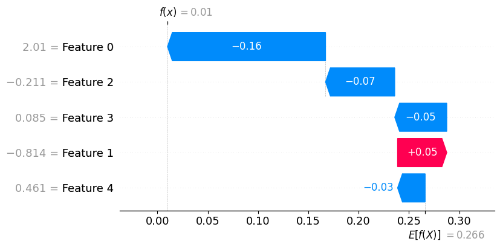

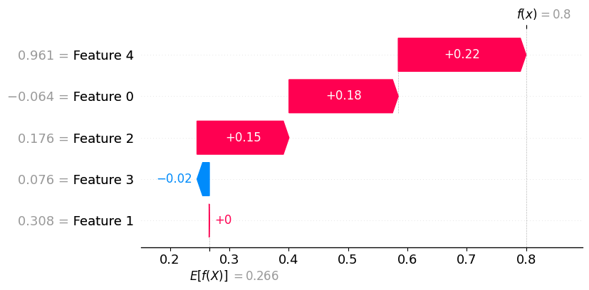

```python
mod = pipeline.named_steps['rf_classifier']
preproc  = pipeline.named_steps['scaler']

transformed_data = preproc.transform(X_train)

shap_explainer = shap.explainers.Tree(mod, data=transformed_data, model_output="probability")
shap_values = shap_explainer(transformed_data[samples, :])[:, :, 1]
for i in range(len(samples)):
    shap.plots.waterfall(shap_values[i])
```

```python
#yields same as above
# mod = pipeline.named_steps['rf_classifier']
# preproc  = pipeline.named_steps['scaler']

# transformed_data = preproc.transform(X_train)
# # corr = lambda x: pred(mod, x)

# shap_explainer = shap.Explainer(mod, transformed_data)
# shap_values = shap_explainer(transformed_data[samples, :])[:, :, 1]
# for i in range(len(samples)):
#     shap.plots.waterfall(shap_values[i])
```

```python
all_shap_values = shap_explainer(transformed_data[:, :])[:, :, 1]
```

```
 99%|===================| 8601/8646 [03:30<00:01]
```

## Different variables of most importance

```python
importance = np.abs(all_shap_values.values)
```

```python
idx_0_1 = np.argsort(-(importance[:, 0]+importance[:,1]))[:10]
```

```python
idx_3_4 = np.argsort(-(importance[:, 3]+importance[:, 4]))[:10]
```

```python
idx_0_1
```

```
array([2430, 1073, 2079, 3761, 2944,  888, 3727, 2576, 1642, 3447])
```

```python
idx_3_4
```

```
array([3232, 1731, 3379,  446, 2502, 3154,  233,   24, 1037, 3739])
```

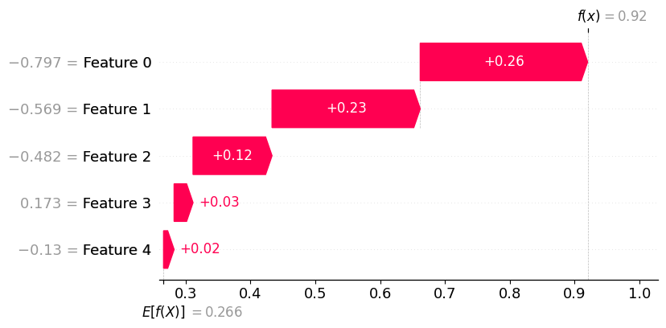

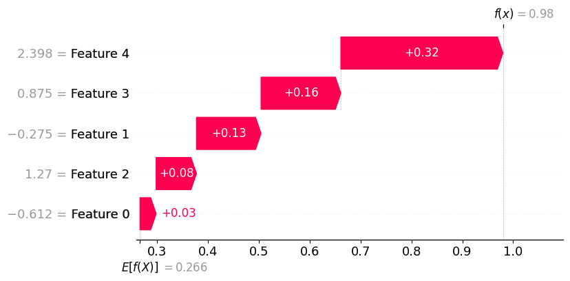

```python
for i in [idx_0_1[0], idx_3_4[0]]:
  shap.plots.waterfall(all_shap_values[i])
```

## Positive and negative attribution of same variable

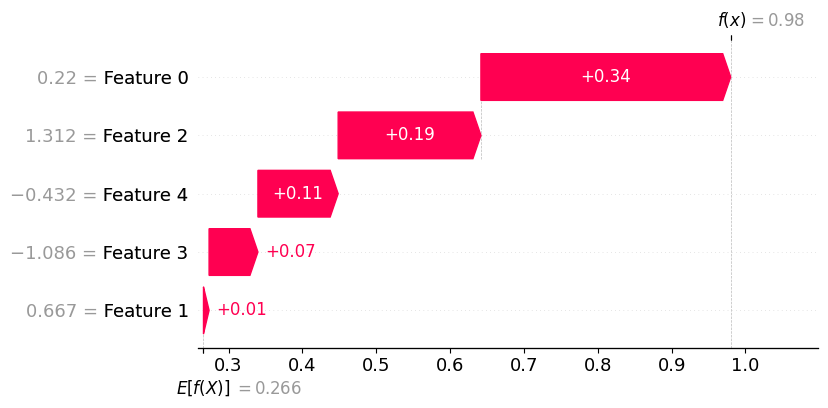

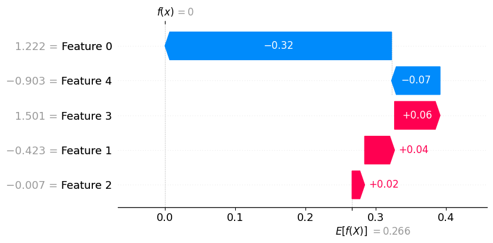

```python
pos_0 = np.argmax(all_shap_values.values[:, 0])
neg_0 = np.argmin(all_shap_values.values[:, 0])
for i in [pos_0, neg_0]:
  shap.plots.waterfall(all_shap_values[i])
```

## Logistic regression with shap

```python
logreg_pipeline = Pipeline([
    ('scaler', StandardScaler()),
    ('model', LogisticRegression())
])
logreg_pipeline.fit(X_train, y_train)
y_pred = logreg_pipeline.predict(X_test)
accuracy = accuracy_score(y_test, y_pred)
print("Accuracy:", accuracy)
score_single(logreg_pipeline, X_train, y_train, X_test, y_test)
```

```
Accuracy: 0.755781683626272
TRAIN:
Accuracy Score: 0.7487855655794587
Precision Score: 0.5933734939759037
Recall Score: 0.46462264150943394
F1 Score: 0.5211640211640213
AUC-ROC Score: 0.8118381642063949
TEST:
Accuracy Score: 0.755781683626272
Precision Score: 0.6050420168067226
Recall Score: 0.4585987261146497
F1 Score: 0.5217391304347826
AUC-ROC Score: 0.8192228801102817
```

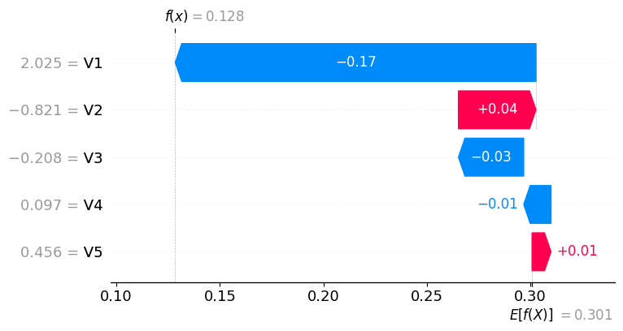

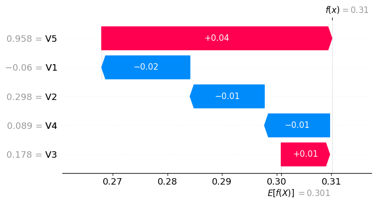

```python
shap_explainer = shap.Explainer(logreg_pipeline.predict_proba, X_train)
shap_values = shap_explainer(X_train.iloc[samples, :])[:, :, 1]
for i in range(len(samples)):
    shap.plots.waterfall(shap_values[i])
```

```python
lr_all = shap_explainer(X_train)[:, :, 1]
```

```
ExactExplainer explainer: 4324it [00:50, 75.77it/s]
```

```python
lr_all.values
```

```
array([[-0.01618039, -0.01361641,  0.00890544, -0.01196245,  0.04216429],
       [ 0.06772944,  0.06580194,  0.00071751,  0.18347902, -0.01876958],
       [-0.17426651,  0.03746609, -0.03153097, -0.01318771,  0.00915667],
       ...,
       [-0.01390838, -0.06562283,  0.05720186, -0.1182061 , -0.0335196 ],
       [ 0.04688155,  0.01993949,  0.00464256,  0.28236147, -0.08294338],
       [ 0.06441238,  0.05552842,  0.11801443,  0.09987298, -0.01879461]])
```

```python
all_shap_values.values
```

```
array([[ 0.18403833,  0.00043833,  0.15498833, -0.02087   ,  0.215305  ],
       [ 0.09186667,  0.20819166,  0.16259166,  0.177775  ,  0.013475  ],
       [-0.15711833,  0.04890667, -0.06875167, -0.05172667, -0.02741   ],
       ...,
       [ 0.076685  , -0.11598167,  0.09146   , -0.096215  , -0.03204833],
       [ 0.08933833,  0.14127167,  0.10068833,  0.21152166,  0.09108   ],
       [-0.105655  ,  0.107095  , -0.099105  , -0.00576333, -0.06267166]])
```

```python
difference = np.sum(np.abs(lr_all.values - all_shap_values.values), axis=1)
```

```python
difference.shape
```

```
(4323,)
```

```python
discord = np.argmax(difference)
```

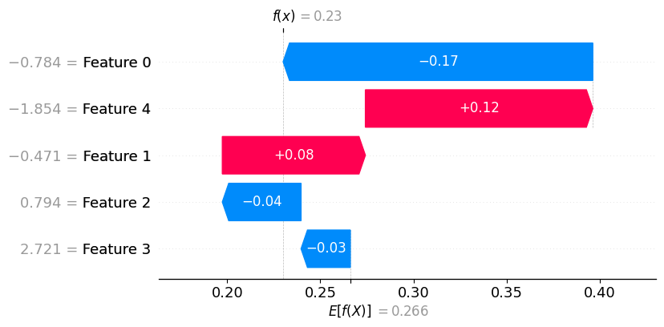

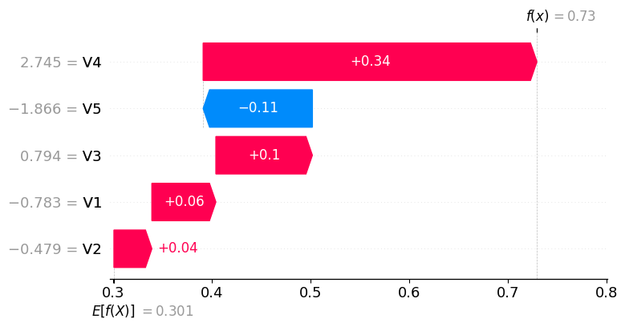

```python
shap.plots.waterfall(all_shap_values[discord])
shap.plots.waterfall(lr_all[discord])
```

Joining empty set: 20, 2 permutations

Joining set B: 60-20=40, 1 permutations

Joining set C: 70-60=10, 1 permutations

Joining set BC: 100-70=30, 2 permutations

Total 6 permutations

(2*20 + 40 + 10 + 2*30)/6 = (40+40+10+60)/6=150/6=25